# Midterm Exam

Bradley Katcher

Due: Mon Oct 14, 2:00pm

**SYS 6018 | Fall 2019 | University of Virginia**

- You may **not** discuss this exam with anyone else. All work must be done independently. You may consult textbooks, online material, etc. but any outside resource must be cited.
  - Add an informal reference (e.g., url, book title) to any source consulted for each problem. But no need to cite class notes.
  - You may reuse code from class notes/homework solutions. E.g., the function `apriori2df()` will make it easier to work with the output from the `arules::apriori()` function.
- Unless otherwise noted, all referenced datasets will be found at directory `https://raw.githubusercontent.com/mdporter/SYS6018/master/data`. In R, the path to these files can be obtained by

```r
data.dir = 'https://raw.githubusercontent.com/mdporter/SYS6018/master/data'
file.path(data.dir, "filename.ext")
```

### Problem 1 (15 pts): A Market Basket of Marvel Heros

In HW 2.1, we analyzed the Marvel Universe using network analytics. This problem will use concepts from Association Analysis to explore the data. Use the dataset `marvel_association.csv`, which gives the heros that appeared in each comic, to answer the following questions. Treat the heros as the *items* and comics as the *transactions*.

1. Provide the following descriptive analysis of the data: the number of items (heros), number of transactions (comics), and a visual representation of the distribution of *the number of items per transaction*.

```r
library(ggplot2)

marvel <- read.csv((url(paste0(data.dir,'//marvel_association.csv'))))

#number of items (heros) unique items (unique heros)
length(marvel$hero)
```

```
#> [1] 96519
```

```r
length(unique(marvel$hero))
```

```
#> [1] 6431
```

```r
#number of transactions (comics) unique transactions (unique comics)
length(marvel$comic)
```

```
#> [1] 96519
```

```r
length(unique(marvel$comic))
```

```
#> [1] 12849
```

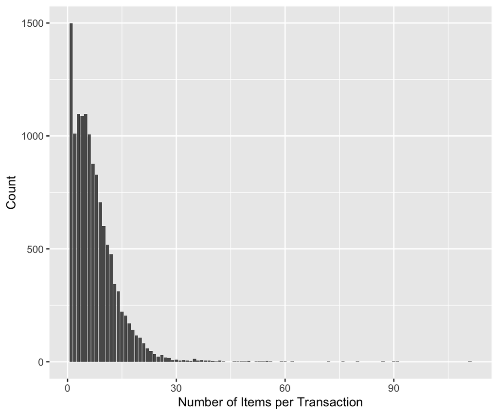

```r
#-- plot the distribution of itemset length (barplot of pmf)
count(marvel, comic) %>%
  ggplot(aes(n)) + geom_bar() + xlab("Number of Items per Transaction") + ylab('Count')
```

```r
#compute number of heros per comic
hpc <- marvel %>% group_by(comic) %>% summarize(nheros = n())
summary(hpc)
```

```
#>      comic           nheros
#>  2001 10:    1   Min.   :  1.000
#>  2001 8 :    1   1st Qu.:  3.000
#>  2001 9 :    1   Median :  6.000
#>  A '00  :    1   Mean   :  7.512
#>  A '01  :    1   3rd Qu.: 10.000
#>  A '98  :    1   Max.   :111.000
#>  (Other):12843
```

There are 96,519 observations of both items (heros) and transactions (comics). In terms of unique items, there are 6,431 unique heros and 12,849 unique comics.

2. What is the *lift* of the itemset: {CAPTAIN AMERICA, SPIDER-MAN}? What does the lift imply about the association of CAPTAIN AMERICA and SPIDER-MAN?

```r
tList <- split(marvel$hero, marvel$comic)
trans <- as(tList, "transactions")

NT <- n_distinct(marvel$comic)

#apriori2df function
apriori2df <- function(x){
  if(class(x) == "itemsets"){
    out = data.frame(items=labels(x), x@quality, stringsAsFactors = FALSE)
  }
  else if(class(x) == "rules"){
    out = data.frame(
      lhs = labels(lhs(x)),
      rhs = labels(rhs(x)),
      x@quality,
      stringsAsFactors = FALSE)
  }
  else stop("Only works with class of itemsets or rules")
  if(require(dplyr)) tbl_df(out) else out
}

itemset = c("CAPTAIN AMERICA", "SPIDER-MAN")
ap <- apriori(trans,
        parameter = list(support=0, target="frequent"),
        appearance = list(items = itemset))
```

[output not shown]

```r
apriori2df(ap) %>%
  mutate(lift = interestMeasure(ap, measure="lift", trans)) %>%
  arrange(-lift)
```

```
#> # A tibble: 3 x 4
#>   items                        support count  lift
#>   <chr>                          <dbl> <int> <dbl>
#> 1 {CAPTAIN AMERICA}             0.105   1352 1.
#> 2 {SPIDER-MAN}                  0.126   1625 1.
#> 3 {CAPTAIN AMERICA,SPIDER-MAN}  0.0113   145 0.848
```

The lift of the itemset {Captain America, Spider-Man} is 0.8480223. Given that lift of the two items is less than one, this implies negative association between the two items, i.e. there are fewer transactions that contain items {Captian America} and {Spider-Man} than would be expected if {Captain America} and {Spider-Man} are independent

3. The [Fantastic Four](https://en.wikipedia.org/wiki/Fantastic_Four) comprises the heros: MR. FANTASTIC, THING, INVISIBLE WOMAN, and HUMAN TORCH. If a comic includes the Fantastic Four, which other hero is most likely to be in the comic? What is the estimated probability?

```r
itemset = c("MR. FANTASTIC", "THING", "INVISIBLE WOMAN", "HUMAN TORCH")

rules2 = apriori(trans,
              parameter = list(support=.0001, confidence=.001, minlen=5,target="rules"),
              appearance = list(lhs = itemset))
```

[output not shown]

```r
ruleResults <- apriori2df(rules2) %>%
                  mutate(addedValue = interestMeasure(rules2, measure="addedValue", trans),
                  PS = interestMeasure(rules2, measure="leverage", trans)) %>%
                  arrange(-confidence) #sort by confidence (the conditional probability of the RHS)

ruleResults
```

```
#> # A tibble: 507 x 8
#>    lhs           rhs      support confidence  lift count addedValue      PS
#>    <chr>         <chr>      <dbl>      <dbl> <dbl> <int>      <dbl>   <dbl>
#>  1 {HUMAN TORCH… {RICHAR… 0.0142       0.310 14.7    182    0.289   1.32e-2
#>  2 {HUMAN TORCH… {MASTER… 0.00988      0.216 13.4    127    0.200   9.15e-3
#>  3 {HUMAN TORCH… {CAPTAI… 0.00763      0.167  1.58    98    0.0614  2.81e-3
#>  4 {HUMAN TORCH… {IRON M… 0.00716      0.156  1.72    92    0.0656  3.00e-3
#>  5 {HUMAN TORCH… {CRYSTA… 0.00677      0.148  7.26    87    0.128   5.84e-3
#>  6 {HUMAN TORCH… {THOR}   0.00646      0.141  1.88    83    0.0661  3.02e-3
#>  7 {HUMAN TORCH… {DR. DO… 0.00638      0.139  6.64    82    0.118   5.42e-3
#>  8 {HUMAN TORCH… {SPIDER… 0.00607      0.133  1.05    78    0.00618 2.83e-4
#>  9 {HUMAN TORCH… {SUB-MA… 0.00506      0.111  2.66    65    0.0690  3.16e-3
#> 10 {HUMAN TORCH… {VISION} 0.00483      0.105  2.24    62    0.0584  2.67e-3
#> # … with 497 more rows
```

If a comic includes Human Torch, Invisible Woman, Mr. Fantastic, and Thing, the most likely other hero in the comic is Franklin B Richards, and the conditional probability of having Franklin B. Richards in the comic is roughly 0.31.

### Problem 2 (15 pts): Hero Clustering

Consider two *binary* vectors $A \in \{0, 1\}^p$ and $B \in \{0, 1\}^p$

- E.g. $A=[0,1,1,1]$, $B = [1,0,1,0]$ for $p=4$.

The dissimilarity, or distance, between two binary vectors can often be created from the following three measures:

- $N_A$ represents the total number of 1’s in A. In example, $N_A = 3$.
- $N_B$ represents the total number of 1’s in B. In example, $N_B = 2$.
- $N_{AB}$ represents the total number of positions where where A and B both have a value of 1. In example, $N_{AB} = 1$ (due to the 3rd position/element of the vectors)
1. Write out the equations for [*cosine distance*](https://en.wikipedia.org/wiki/Cosine_similarity), [*Jaccard’s distance*](https://en.wikipedia.org/wiki/Jaccard_index), and [*Squared Euclidean distance*](https://en.wikipedia.org/wiki/Euclidean_distance#Squared_Euclidean_distance) using $N_{AB}, N_A, N_B$. Note: use 1-similarity to convert a similarity scores to a *distance*.

Cosine Distance:
$$1-\frac{N_{AB}}{\sqrt{N_{A}}*\sqrt{N_{B}}}$$

Jaccard’s Distance:
$$1-\frac{N_{AB}}{N_{A}+N_{B}-N_{AB}}$$

Squared Euclidian Distance:

$$(N_A - N_{AB}) + (N_B - N_{AB})$$

2. The Marvel Heros INVISIBLE WOMAN and THING appeared in $668$ comics together. Use the data from Problem 1 to calculate the three *distances* between INVISIBLE WOMAN and THING.
   - The vectors represent the presence or absence of the heros in each comic

```r
#load libraries
library(dplyr)
library(questionr)

#create unique list of comics
comics <- data.frame(unique(marvel$comic))
comics <- rename.variable(comics, 'unique.marvel.comic.','comic')

#find comics with the two heroes in them
thing <- subset(marvel, hero == 'THING')
invisible <- subset(marvel, hero == 'INVISIBLE WOMAN')

#join to create 0,1 vectors for presence of hero in comic
thing <- left_join(comics,thing)
thing$hero <- ifelse(is.na(thing$hero), 0, 1)

invisible <- left_join(comics,invisible)
invisible$hero <- ifelse(is.na(invisible$hero),0,1)

thing <- c(thing$hero)
invisible <- c(invisible$hero)
```

Create $N_{A}$, $N_{B}$, and $N_{AB}$ measures to use in calculations

```r
na <- sum(thing)
nb <- sum(invisible)
nab <- sum(pmax(thing+invisible-1,0))
```

Cosine Distance:

```r
1-nab/(sqrt(na)*sqrt(nb))
```

```
#> [1] 0.2408012
```

Jaccard’s Distance:

```r
1- (nab)/(na+nb-nab)
```

```
#> [1] 0.3949275
```

Squared Euclidian Distance:

```r
(na-nab) + (nb-nab)
```

```
#> [1] 436
```

3. The dendrogram below is constructed by running hierarchical clustering using *Jaccard’s Distance* and *Single Linkage* on the 30 most frequent heros. Describe the first 3 merges. Who gets merged, at what (approximate) height are they merged, and how single linkage is used to calculate the height.

[figure not shown]

1. Invisible Woman merged with Mr. Fantastic at height 0.28
2. (Invisible Woman and Mr. Fantastic) merged with Human Torch at height 0.30
3. (Invisible Woman and Mr. Fantastic and Human Torch) merged with Thing at height 0.36

Single linkage uses the smallest dissimilarity (Jaccard’s distance in this case) between pairs in the two sets in order to calculate the height.

4. The dendrogram below is constructed by running hierarchical clustering using *Cosine Distance* and *Complete Linkage* on the 30 most frequent heros. How many clusters result if the dendrogram is cut at a height of 0.70?

What is the largest possible Cosine Distance between THOR and SCARLET WITCH?

[figure not shown]

If we cluster based on the dendrogram at a height of 0.70, there will be 11 clusters.

Since we are using complete linkage (the largest dissimilarity between pairs in two sets) and cosine distance, the largest possible distance between THOR and SCARLET WITCH is simply the height, which is at approximately 0.75.

### Problem 3 (15 pts): Predictive Density Estimation Contest

In HW 3.2, you estimated the (space-time) density of highway crashes on I-64 in 2016 using Kernel Density Estimation (KDE). In this problem, you will re-estimate the density, using the method of your choice, with the goal of predicting the density of the crashes in 2017.

This will be a contest. You will submit your 2017 density estimates at a set of evaluation grid points and I will evaluate your predictions using the predictive log-likelihood ratio (or information gain) score:
$$score = \sum_{i=1}^n \log \frac{\hat{f}(mile_i, time_i)}{p(mile_i, time_i)}$$
where $\hat{f}(m, t)$ is your prediction for $(mile=m, time=t)$, $p(m, t)$ is my predictions, and the sum is over the $n$ points in the 2017 test data. A positive score means that you did better than my predictions - you will receive a 4% bonus on your exam score!

1. Use the same data that was given in HW 3.2, `crashes16.csv`, to make your predictive density estimate. Make predictions at the grid points

```r
eval.pts = expand.grid(mile = seq(86.9, 136.1, by=.25), time = seq(0, 7, by=1/24))
```

Create a .csv file named `lastname_firstname.csv` that includes the columns named *mile*, *time*, *f*, where *f* is your estimated density. - Submit this file in Collab (along with your .Rmd and .html) - Show your code that makes the predictions.

```r
set.seed(2019)

eval.pts <- expand.grid(mile = seq(86.9, 136.1, by=.25), time = seq(0, 7, by=1/24))


crashData <- read.csv(paste0(data.dir,'/crashes16.csv'))

#---------------------------------------------------------------------------#
#-- Employ MBC  (based on BIC)
#---------------------------------------------------------------------------#
# Use the mclust package to help search across all K's
library(mclust) #load mclust
mixtureModel <- Mclust(crashData)
summary(mixtureModel)   # finds clusters
```

```
#> ----------------------------------------------------
#> Gaussian finite mixture model fitted by EM algorithm
#> ----------------------------------------------------
#>
#> Mclust EEI (diagonal, equal volume and shape) model with 4 components:
#>
#>  log-likelihood   n df       BIC       ICL
#>       -2703.018 456 13 -5485.628 -5611.533
#>
#> Clustering table:
#>   1   2   3   4
#> 120  97 143  96
```

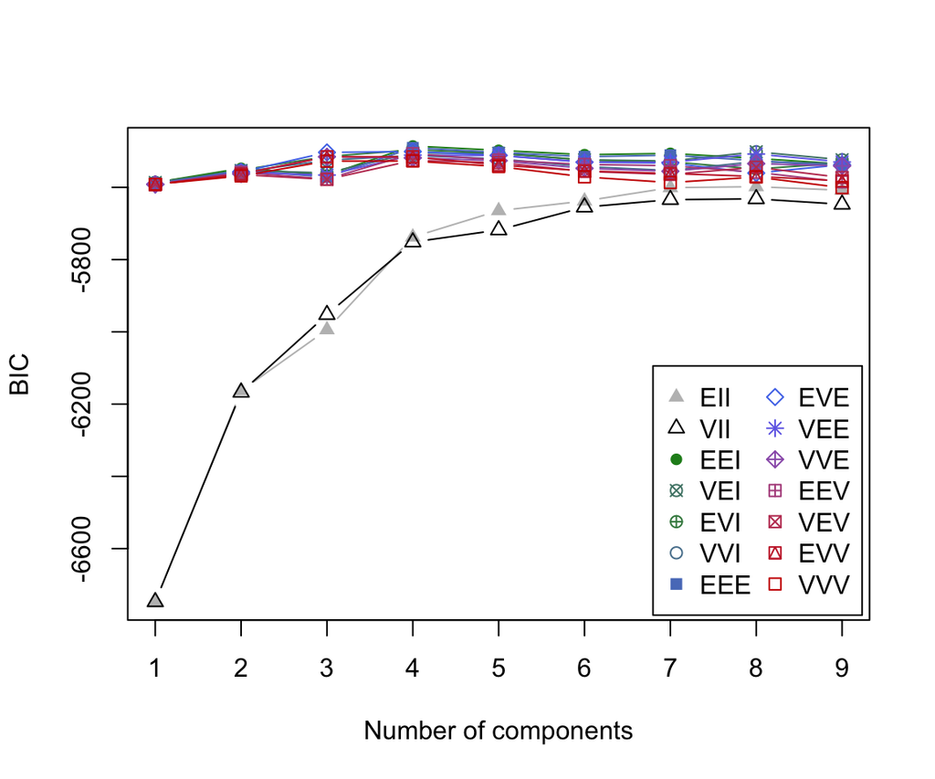

```r
#plots
plot(mixtureModel, what="BIC")
```

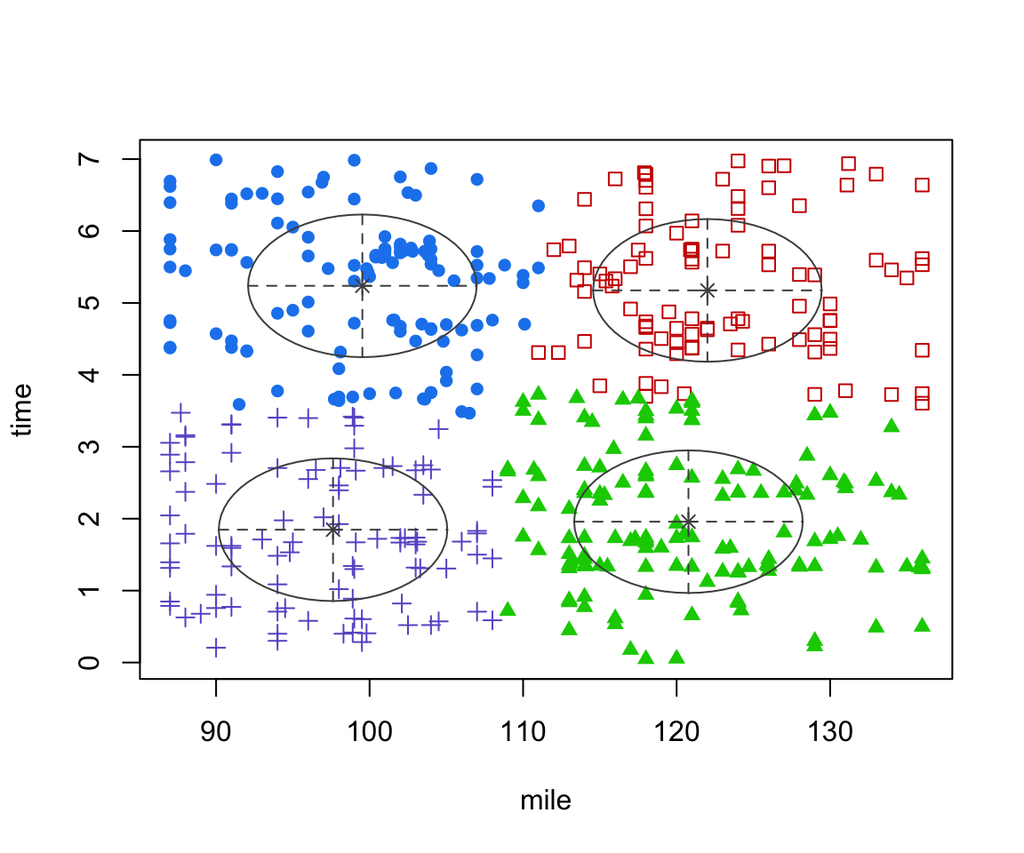

```r
plot(mixtureModel, what="classification")
```

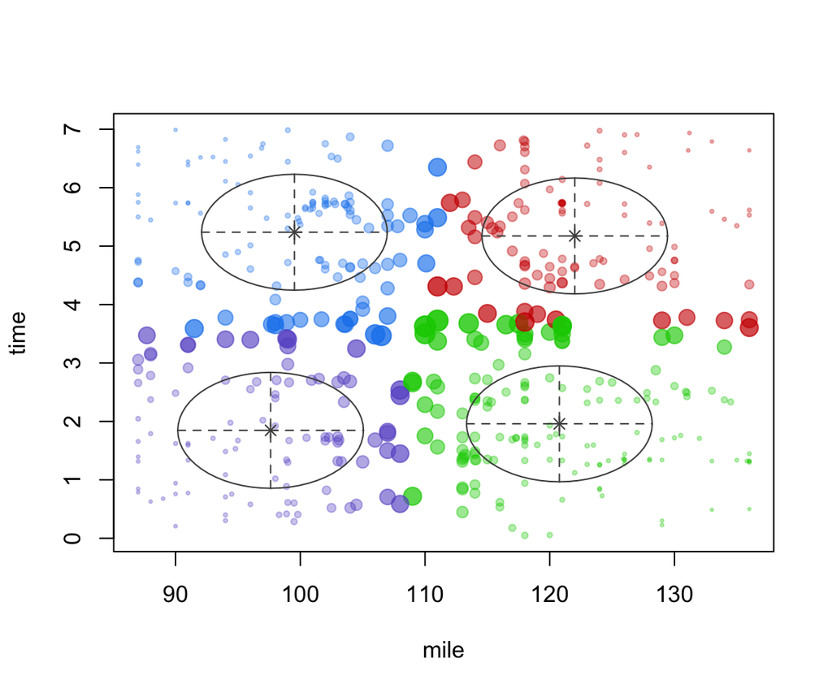

```r
plot(mixtureModel, what="uncertainty")
```

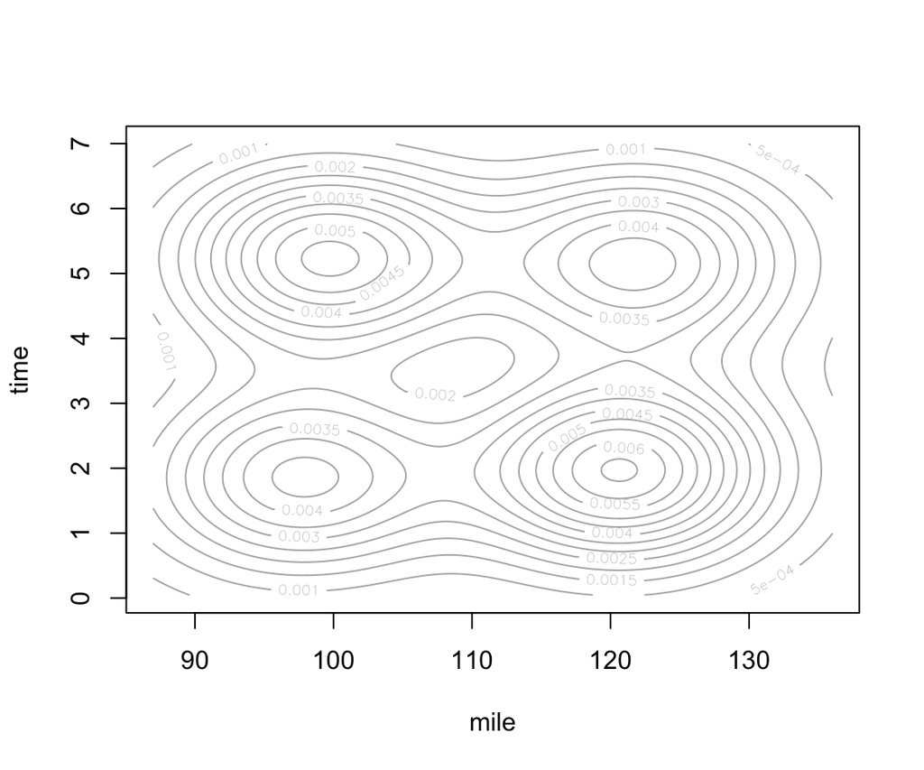

```r
plot(mixtureModel, what="density")
```

```r
#-- get parameters
summary(mixtureModel, parameters=TRUE)
```

```
#> ----------------------------------------------------
#> Gaussian finite mixture model fitted by EM algorithm
#> ----------------------------------------------------
#>
#> Mclust EEI (diagonal, equal volume and shape) model with 4 components:
#>
#>  log-likelihood   n df       BIC       ICL
#>       -2703.018 456 13 -5485.628 -5611.533
#>
#> Clustering table:
#>   1   2   3   4
#> 120  97 143  96
#>
#> Mixing probabilities:
#>         1         2         3         4
#> 0.2613032 0.2205107 0.3030802 0.2151058
#>
#> Means:
#>           [,1]       [,2]      [,3]      [,4]
#> mile 99.528038 122.005442 120.77110 97.619132
#> time  5.237977   5.174534   1.95831  1.846726
#>
#> Variances:
#> [,,1]
#>          mile      time
#> mile 55.42664 0.0000000
#> time  0.00000 0.9838526
#> [,,2]
#>          mile      time
#> mile 55.42664 0.0000000
#> time  0.00000 0.9838526
#> [,,3]
#>          mile      time
#> mile 55.42664 0.0000000
#> time  0.00000 0.9838526
#> [,,4]
#>          mile      time
#> mile 55.42664 0.0000000
#> time  0.00000 0.9838526
```

```r
# create predictions based on the evaluation points
densityPoints <- densityMclust(eval.pts)

#store density estimations
eval.pts$f <- densityPoints$density

#write to csv
write.csv(eval.pts, 'katcher_bradley.csv')

max(eval.pts$f)
```

```
#> [1] 0.004614164
```

2. Describe the model you used. Make sure to mention why you chose your model, what the unknown parameters in your model are, and how those parameters were estimated. You may need to read the function documentation; I’m not looking for the mathematical details but do need to specify the method used.

I ran model-based clustering using finite Gaussian mixutre models (the Mclust function from the mclust package). The models are estimated by the EM algorithm, initalized by hierarchical model-based clustering, and chosen based on the BIC.

The ultimate model that this produced is a multivariate mixture with K = 4, where the clusters are diagonal of equal volume and shape, as this is where the BIC was the highest.

I chose to do model based clustering because I believe that there are multiple distributions of crashes throughout I-64 that may not be of equal shapes and sizes, so it would allow non-speherical clusters, different sizes, and different variances/densities, and model based clustering facilitates this fairly well.

The parameters that were estimated include the cluster means for the mile and time variables, the mixing probabiliites of the different clusters, and the variance-covariance matricies for each of the clusters.

### Problem 4 (5 pts): Network Clustering

It was mentioned in class (or class notes) that *community detection* could be considered as a clustering of the nodes in a network. *Spectral clustering* is a clustering approach that uses the eigenvectors from the graph *Laplacian* as the features for clustering. In this exercise you will implement a version of spectral clustering. More specifically, the spectral clustering algorithm for $K$ clusters is as follows:

1. Find the eigenvectors associated with the $K$ *smallest, non-zero* eigenvalues of the graph Laplacian $L$.
2. Run $k$-means clustering to find $K$ clusters using the $K$ eigenvectors as the features/variables.

Use the Laplacian $L = D-A$, where $D$ is the diagonal matrix with node degree along the diagonal and $A$ is the (unweighted) adjacency matrix.

Hints: the R function `eigen()` finds the eigenvalues and eigenvectors of a matrix. There will be one $0$ eigenvalue in this problem, but due to round-off error it will have a value on the order of $10^{-16}$; do not include the eigenvector associated with this zero eigenvalue when running $k$-means.

1. The `UKfaculty` network found in the `igraphdata` R package is a social network of university faculty. The graph can be loaded into R with the command `data(UKfaculty, package='igraphdata')`. Calculate the graph Laplacian using an undirected and unweighted version of the graph.
   - Show the code used to produce $L$.

```r
#load libraries
library(igraphdata)
library(igraph)

#load graph and convert it to a dataframe
# According to the package (https://www.rdocumentation.org/packages/igraphdata/versions/1.0.1/topics/UKfaculty), this graph object is weighted and directed, so I convert it to a dataframe of edges and use that create an unweighted and undirected graph
data(UKfaculty, package='igraphdata')
UKframeEdges <- as_data_frame(UKfaculty, what = 'edges')
UKframeEdges <- UKframeEdges[c('to', 'from')]

#creating an unweighted and undirected graph
UKgraph <- graph_from_data_frame(UKframeEdges, directed = FALSE)


#checking to make sure it isn't weighted or directed
is.directed(UKgraph)
```

```
#> [1] FALSE
```

```r
is.weighted(UKgraph)
```

```
#> [1] FALSE
```

```r
#creating a laplacian matrix (https://igraph.org/r/doc/laplacian_matrix.html) using the laplacian matrix command - incldue weights = NA so the graph is unweighted
laplacian <- as.matrix(laplacian_matrix(UKgraph, normalized = FALSE, weights = NA))
```

2. Implement spectral clustering of the `UKfaculty` network using $K=1,2,\ldots, 9$.
   - Show your code.
   - Also plot the sum of squared errors (SSE) as a function of $k$

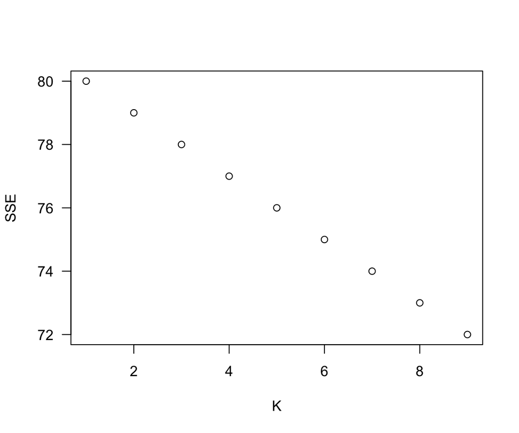

```r
ev<- eigen(laplacian)$vectors

#drop the last eigenvector that is associated with the zero eigenvalue
ev <- ev[,1:80]

#run k-means clustering:
Kmax = 9
SSE = numeric(Kmax)                       # initiate SSE vector
for(k in 1:Kmax){
  km = kmeans(ev, centers=k, nstart=25)    # use 25 starts
  SSE[k] = km$tot.withinss                # get SSE
}

plot(SSE, xlab="K", las=1)
```

3. Estimate $K$. Explain why you chose that value of $K$.

Normally, we would choose a value of K that is at a kink or elbow point, however, since this graph is linear, I am going to choose a point that is in the middle, so I choose the value of k = 4.

4. Using your chosen value of $K$, evaluate how well the resulting clustering can distinguish between the school affiliation of the nodes. Use the vertex attribute `Group` (in the `UKfaculty` graph) as the true label and calculate how many nodes would be *misclassified* by the clustering.

```r
#run k-means clustering for spectral clustering
set.seed(112341)
km <- kmeans(ev, centers=4, nstart=50) # use K=4
```

```r
#Evaluate the classification ability of K-means
table(true=V(UKfaculty)$Group, est=km$cluster)
```

```
#>     est
#> true  1  2  3  4
#>    1 33  0  0  0
#>    2 23  1  2  1
#>    3 17  1  0  1
#>    4  2  0  0  0
```

Using k = 4, 36 school affiliations are correctly predicted out of 81, with the rest being misclassified Largely, the clustering cannot distinguish well between the school affiliation of nodes. This is because the spectral clustering categorizes the vast majority of nodes into one cluster (75 out of the 81).